# Reproducible Report Demo

Lisa DeBruine

## Intro

The study asked 389 subjects to complete a 15-item disgust scale and report their age, gender, and whether they were monolingual or bilingual. Subjects were in one of two conditions (A or B) and one of two versions (One or Two).

The script uses the following packages: tidyverse (Wickham et al. 2019).

## Demographics

### Full Data Set

See Table 1.

Table 1: The number of bilingual and monolingial subjects per conditon and version in the full data set (pre-exclusions).

| condition | version | bilingual | monolingual | total |
| --- | --- | --- | --- | --- |
| A | One | 32 | 66 | 98 |
| A | Two | 28 | 69 | 97 |
| B | One | 28 | 69 | 97 |
| B | Two | 27 | 70 | 97 |

#### Age

Figure 1 shows that the age distributions were roughly similar between conditions, versions, and languages.

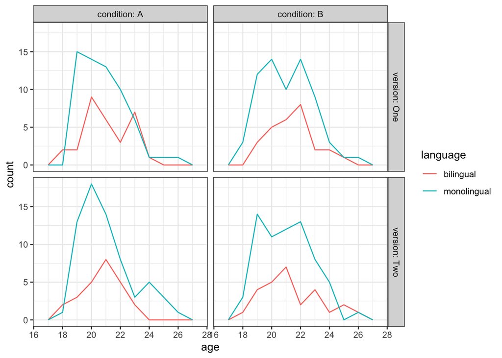

Figure 1: Age distributions by language, condition, and version

#### Gender

There were no obvious differences in the gender distribution between languages, conditions, and versions. However, there were more men (222) than women (104), non-binary people (44), and people who did not answer the gender question (19).

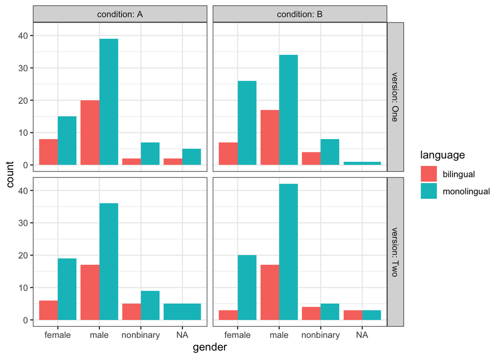

Figure 2: Gender by language, condition, and version

### Exclusions

Because we were only looking at the effect of condition on disgust score for monolingual subjects, we excluded 147 subjects who were bilingual or had missing disgust scores, leaving 242 subjects for the analysis.

Table 2: The number of subjects per conditon and version in the analysed data set (post-exclusions).

| condition | version | n |
| --- | --- | --- |
| A | One | 58 |
| A | Two | 59 |
| B | One | 64 |
| B | Two | 61 |

#### Age

Figure 3 shows that the age distributions were roughly similar between conditions and versions.

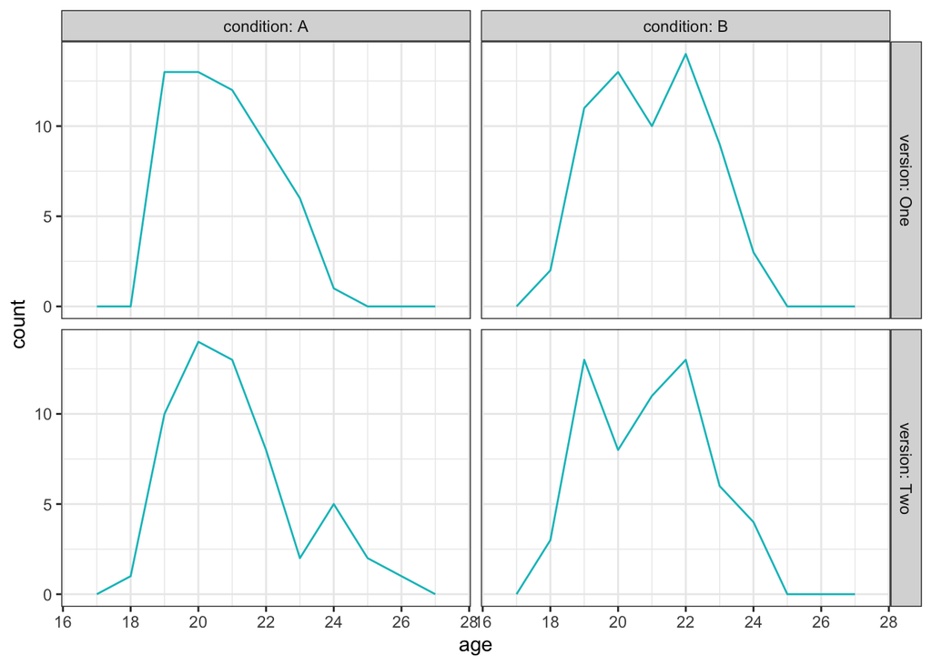

Figure 3: Age distributions by language, condition, and version

#### Gender

The gender distribution between conditions and versions showed that there were more women in cndition B than condition A. There were more men (134) than women (71), non-binary people (27), and people who did not answer the gender question (10).

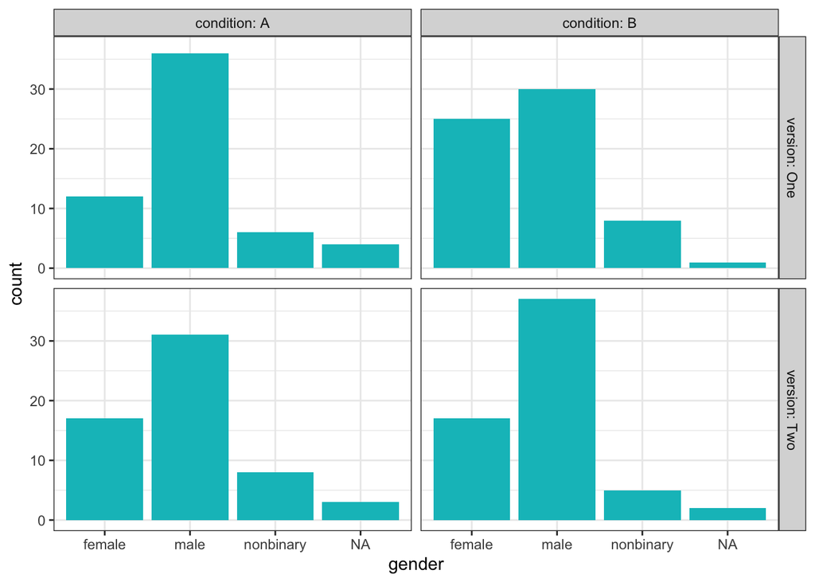

Figure 4: Gender by language, condition, and version

## Analysis

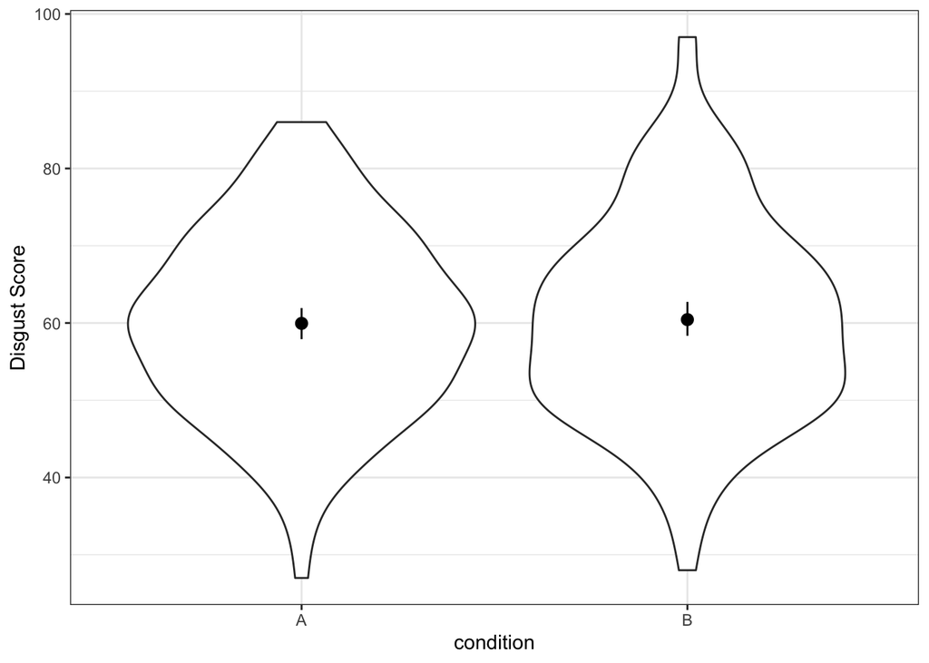

Figure 5: Disgust scores by condition for the monolingual subjects. The dot is the mean and error bars represent the 95% CI.

Condition was effect-coded such that condition A = -0.5 and condition B = 0.5.

Table 3: Results of the linear model predicting disgust score from condition.

| Term | Estimate | SE | t-value | p-value | 95% CI |
| --- | --- | --- | --- | --- | --- |
| (Intercept) | 60.19 | 0.8 | 75.10 | 0.00 | [58.62 – 61.77] |
| condition.e | 0.49 | 1.6 | 0.31 | 0.76 | [-2.67 – 3.65] |

## Power

Here, we assume an equal number of people in conditions A and B.

## References

Wickham, Hadley, Mara Averick, Jennifer Bryan, Winston Chang, Lucy D’Agostino McGowan, Romain François, Garrett Grolemund, et al. 2019. “Welcome to the tidyverse.” *Journal of Open Source Software* 4 (43): 1686. https://doi.org/10.21105/joss.01686.